# Causal Inference - Exercise IV

Job Corps

Michael Knaus

SoSe 25

These are the goals of today:

- Recap parts of LATE identification
- Calculate LATE and the other quantities we identified in the lecture manually and using suitable functions

# Intention to treat effect identification

Recap the consistency assumption (CA) with respect to outcome
$$Y = Y(z,W(z)) \text{ if } Z = z$$
and the independence assumption (IA)
$$Y(z,W(z)) \perp\!\!\!\!\perp
Z~\forall~z\in\{0,1\}$$

Now show identification of the intention-to-treat effect *on the outcome*:
$$\begin{align*}
SUTVA \Rightarrow E[Y(1,W(1)) - Y(0,W(0))] & = E[Y(1,W(1))] -
E[Y(0,W(0))] & (LOE) \\
& = E[Y(1,W(1)) | Z = 1] - E[Y(0,W(0)) | Z=0]& (IA) \\
& = E[Y \mid Z = 1] - E[Y \mid Z = 0] & (CA)
\end{align*}$$

# Analyzing Job Corps data

```
# Install and load all relevant packages for this session
if (!require("estimatr")) install.packages("estimatr", dependencies = TRUE); library(estimatr)
if (!require("haven")) install.packages("haven", dependencies = TRUE); library(haven)
if (!require("AER")) install.packages("AER", dependencies = TRUE); library(AER)
if (!require("tidyverse")) install.packages("tidyverse", dependencies = TRUE); library(tidyverse)
if (!require("devtools")) install.packages("devtools", dependencies = TRUE); library(devtools)
if (!require("ivdesc")) devtools::install_version("ivdesc",version="1.1.1"); library(ivdesc)
```

## Load the Job Corps data

The famous Job Corps (JC) contains data from an RCT. JC operates since 1964 and is the largest training program for disadvantaged youth aged 16-24 in the US. The roughly 50,000 participants per year receive an intensive treatment as a combination of different components like academic education, vocational training, and job placement assistance. Participants plan their educational and vocational curricula together with counselors.

Individuals interested in participating were randomly assigned to JC, but the data show substantial non-compliance.

The data are available [here](https://journaldata.zbw.eu/dataset/who-benefits-from-job-corps-a-distributional-analysis-of-an-active-labor-market-program/resource/2ffd00ee-e8ed-4442-b8c8-f74a4620a27a?inner_span=True)

```
df = read_dta("https://journaldata.zbw.eu/dataset/c77de6cc-3100-49ea-83a3-a993f2d6d984/resource/392a2af2-f8b2-4580-81ba-41abe5920293/download/eren-ozbeklik-data.dta")

df = df %>%
  select(EARNY4, participation, assignment, female, age_cat, haschld, potuse, everwork) %>%
  filter(haschld != 999) %>%
  na.omit()

X = df %>% select(female, age_cat, haschld, potuse, everwork)
Z = df$assignment
W = df$participation
Y = df$EARNY4
```

## First descriptives

How many assigned to treatment?

```
table(Z)
```

```
Z
   0    1
4189 6259
```

How many actually receive it?

```
table(W)
```

```
W
   0    1
5835 4613
```

Cross-table instrument and treatment to check how many always- and never-taker are in the sample:

```
table(W,Z)
```

```
   Z
W      0    1
  0 4141 1694
  1   48 4565
```

Then plot the distribution of the outcome “weekly earning in dollars four years after random assignment”:

```
hist(Y, breaks = 40)
```

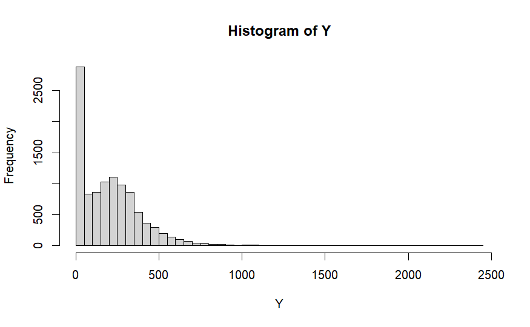

and the outcome mean

```
mean(Y)
```

```
[1] 204.67
```

## Intention-to-treat effects

Calculate the ITT on the treatment a.k.a. the first stage a.k.a. the complier share as

$$ITT_W = E[W \mid Z = 1] - E[W \mid Z =
0]$$

```
ittw = mean(W[Z == 1]) - mean(W[Z == 0])
ittw
```

```
[1] 0.7178912
```

Calculate ITT on the outcome:

$$ITT_Y = E[Y \mid Z = 1] - E[Y \mid Z =
0]$$

```
itty = mean(Y[Z == 1]) - mean(Y[Z == 0])
itty
```

```
[1] 12.28843
```

Run OLS to test significance of the mean differences

```
summary(lm_robust(W ~ Z))
```

```
Call:
lm_robust(formula = W ~ Z)

Standard error type:  HC2

Coefficients:
            Estimate Std. Error t value  Pr(>|t|) CI Lower CI Upper    DF
(Intercept)  0.01146   0.001645   6.967 3.423e-12 0.008235  0.01468 10446
Z            0.71789   0.005852 122.671 0.000e+00 0.706420  0.72936 10446

Multiple R-squared:  0.502 ,    Adjusted R-squared:  0.502
F-statistic: 1.505e+04 on 1 and 10446 DF,  p-value: < 2.2e-16
```

```
summary(lm_robust(Y ~ Z))
```

```
Call:
lm_robust(formula = Y ~ Z)

Standard error type:  HC2

Coefficients:
            Estimate Std. Error t value Pr(>|t|) CI Lower CI Upper    DF
(Intercept)   197.31      2.919  67.603 0.000000  191.587   203.03 10446
Z              12.29      3.862   3.182 0.001467    4.718    19.86 10446

Multiple R-squared:  0.0009466 ,    Adjusted R-squared:  0.0008509
F-statistic: 10.12 on 1 and 10446 DF,  p-value: 0.001467
```

## Calculate LATE and friends

The assumption of monotonicity seems plausible in our setting and we therefore can calculate the local average treatment effect
$$\tau_{LATE} := E[Y(1) - Y(0) \mid T = c] =
\frac{ITT_Y}{ITT_W}$$

```
late = itty / ittw
late
```

```
[1] 17.1174
```

Get also the S.E.s using TSLS

```
summary(ivreg(Y ~ W | Z ))
```

```
Call:
ivreg(formula = Y ~ W | Z)

Residuals:
    Min      1Q  Median      3Q     Max
-214.23 -168.43  -23.21  100.70 2212.80

Coefficients:
            Estimate Std. Error t value Pr(>|t|)
(Intercept)  197.112      3.072  64.166  < 2e-16 ***
W             17.117      5.441   3.146  0.00166 **
---
Signif. codes:  0 ‘***’ 0.001 ‘**’ 0.01 ‘*’ 0.05 ‘.’ 0.1 ‘ ’ 1

Residual standard error: 195.7 on 10446 degrees of freedom
Multiple R-Squared: 0.0008623,  Adjusted R-squared: 0.0007666
Wald test: 9.896 on 1 and 10446 DF,  p-value: 0.001661
```

Furthermore calculate shares of types:

- $\pi_{nt} := P(T = nt) = P(W = 0 \mid Z = 1)$ the share of never-takers
- $\pi_{at} := P(T = at) = P(W = 1 \mid Z = 0)$ the share of always-takers
- $\pi_{c} := P(T = c) = 1 - \pi_{at} - \pi_{nt}$ the complier share

```
pi_nt = mean(1-W[Z == 1])
pi_at = mean(W[Z == 0])
pi_c  = 1 - pi_nt - pi_at

print(rbind("Share of never-takers:" = round(pi_nt, 2),
            "Share of always-takers:" = round(pi_at, 2),
            "Share of compliers:" = round(pi_c, 2)))
```

```
                        [,1]
Share of never-takers:  0.27
Share of always-takers: 0.01
Share of compliers:     0.72
```

Interestingly, there are very few always-takers (“one-sided non-compliance”).

If there were no always-takers at all, then anyone who is treated would necessarily be a complier, and the LATE could be interpreted as the average effect on the treated (ATT).

Calculate APO under control for never-takers

$$E[Y(0) | T = nt] = E[Y | Z = 1, W =
0]$$

```
APO_Y0_nt = mean(Y[Z == 1 & W == 0])
APO_Y0_nt
```

```
[1] 203.6699
```

Calculate APO under treatment for always-takers

$$E[Y(1) | T = at] = E[Y | Z = 0, W =
1]$$

```
APO_Y1_at = mean(Y[Z == 0 & W == 1])
APO_Y1_at
```

```
[1] 196.3613
```

Calculate APO under control for compliers

$$E[Y(0)| T =c ] = \frac{\pi_{nt} +
\pi_{c}}{\pi_{c}} E[Y | Z = 0, W = 0] - \frac{\pi_{nt}}{\pi_{c}} E[Y | Z
= 1, W = 0]$$

```
APO_Y0_co = (pi_nt + pi_c) / pi_c * mean(Y[Z == 0 & W == 0]) - pi_nt / pi_c * mean(Y[Z == 1 & W == 0])
APO_Y0_co
```

```
[1] 194.9253
```

Calculate APO under treatment for compliers

$$E[Y(1)| T =c ] = \frac{\pi_{at} +
\pi_{c}}{\pi_{c}} E[Y | Z = 1, W = 1] - \frac{\pi_{at}}{\pi_{c}} E[Y | Z
= 0, W = 1]$$

[output not shown]

[output not shown]

Plot the results:

```
# Create data frame
data = data.frame(
  Group = rep(c("Compliers", "Always Takers", "Never Takers", "Defiers"), each = 2),
  Treatment = rep(c("E[Y(1)]", "E[Y(0)]"), 4),
  APO = c(APO_Y1_co, APO_Y0_co, APO_Y1_at, NA, NA, APO_Y0_nt, NA, NA))

# Plot using ggplot2
ggplot(data, aes(x = Treatment, y = APO, fill = Treatment)) +
  geom_col(na.rm = TRUE, width = 0.4) +
  facet_wrap(~ Group, ncol = 2) +
  coord_cartesian(ylim = c(150, NA)) +
  labs(y = "Average Potential Outcome", x = "", title = "APOs by treatment and type") +
  theme(legend.position = "none", strip.text = element_text(face = "bold"))
```

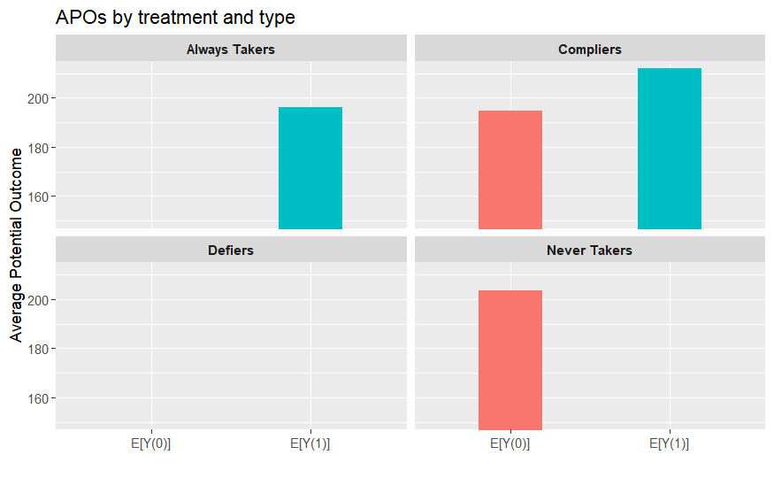

Sanity check if difference produces LATE as expected:

```
all.equal(late,APO_Y1_co - APO_Y0_co)
```

```
[1] TRUE
```

## Potential outcome distributions

We can plot the respective potential outcome distributions for never-takers and always-takers. For compliers, we can even compare the PO distributions under treatment and control to study how the treatment affects the outcome distribution.

Calculate cdf under control for compliers

$$F_{Y(0)|T}(y(0) | c) = \frac{\pi_{nt} + \pi_c}{\pi_c} F_{Y|Z,W}(y | 0,0)
- \frac{\pi_{nt}}{\pi_c} F_{Y|Z,W}(y | 1,0)$$

Calculate cdf under treatment for compliers

$$F_{Y(1)|T}(y(1) | c) = \frac{\pi_{at} + \pi_c}{\pi_c} F_{Y|Z,W}(y | 1,1)
- \frac{\pi_{at}}{\pi_c} F_{Y|Z,W}(y | 0,1)$$

```
ecdf_Y0_nt  = ecdf(Y[Z == 1 & W == 0])
ecdf_Y1_at  = ecdf(Y[Z == 0 & W == 1])
ecdf_Y0_ntc = ecdf(Y[Z == 0 & W == 0])
ecdf_Y1_atc = ecdf(Y[Z == 1 & W == 1])

grid_points =  seq(min(Y), max(Y), length.out = 500) # Smooth evaluation grid

# Calculate the weighted differences between the two cdfs
F_Y0_c = ((pi_nt + pi_c) / pi_c) * ecdf_Y0_ntc(grid_points) - (pi_nt / pi_c) * ecdf_Y0_nt(grid_points)
F_Y1_c = ((pi_at + pi_c) / pi_c) * ecdf_Y1_atc(grid_points) - (pi_at / pi_c) * ecdf_Y1_at(grid_points)
```

And calculate empirical cdfs for the observed outcomes:

```
ecdf_Y0 = ecdf(Y[W == 0])
ecdf_Y1 = ecdf(Y[W == 1])
```

We can now plot the distributions, setting `xlim = c(0,800)` to make sure we don’t miss the action:

```
# Define the plotting function
figure = function(F_Y0, F_Y1, title, labels, grid_points) {
  plot(grid_points, F_Y0, type = "l", col = "#1b9e77", lwd = 2.5,
       main = title, xlab = "Weekly Earnings, $", ylab = "CDF",
       las = 1, ylim = c(0,1), xlim = c(0,800))
  grid(nx = NULL, ny = NULL, col = "gray", lty = "dotted", lwd = 1)
  lines(grid_points, F_Y1, col = "#d95f02", lwd = 2.5)
  legend("bottomright", legend = labels,
         col = c("#1b9e77", "#d95f02"), lty = 1, lwd = 2.5, bty = "n", cex = 1.1)
}

par(mfrow = c(1, 2), mar = c(4, 4, 3, 2) + 0.1, pty = "s")
figure(F_Y0_c, F_Y1_c, "Potential Outcomes for Compliers",
       c(expression(Y(0)~"|"~T~"="~c), expression(Y(1)~"|"~T~"="~c)), grid_points)
figure(ecdf_Y0(grid_points), ecdf_Y1(grid_points), "Observed Outcomes",
       c(expression(Y~"|"~W~"="~0), expression(Y~"|"~W~"="~1)), grid_points)
```

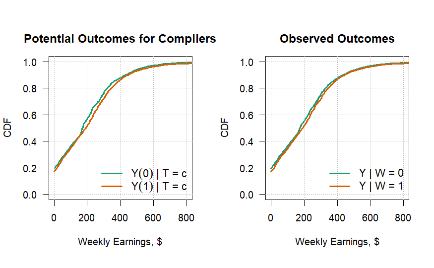

## Characterizing types

Finally we characterize the different groups in terms of observable characteristics:

Never-takers:

```
Xmean_nt = colMeans(X[Z==1 & W==0,])
Xmean_nt
```

```
    female    age_cat    haschld     potuse   everwork
 0.5206612 18.7804014  0.2626919  0.2308146  0.8223140
```

Always-takers:

```
Xmean_at = colMeans(X[Z==0 & W==1,])
Xmean_at
```

```
    female    age_cat    haschld     potuse   everwork
 0.3125000 18.3541667  0.1458333  0.2916667  0.8125000
```

Compliers:
$$E[X \mid T=c] = \frac{E[X] -
E[X \mid W=0,Z=1] \pi_{nt} - E[X \mid W=1,Z=0]
\pi_{at}}{\pi_c}$$

```
Xmean_co = (colMeans(X) - Xmean_nt * pi_nt - Xmean_at * pi_at) / pi_c

print(rbind("Never-taker" = round(Xmean_nt, 2),
            "Always-taker" = round(Xmean_at, 2),
            "Complier" = round(Xmean_co, 2)))
```

```
             female age_cat haschld potuse everwork
Never-taker    0.52   18.78    0.26   0.23     0.82
Always-taker   0.31   18.35    0.15   0.29     0.81
Complier       0.39   18.26    0.18   0.25     0.79
```

Additionally, we can get standard errors via bootstrap to make inferences about types’ characteristics

```
set.seed(42)
dat_long = data.frame(W, Z, X) %>% gather(var, val, -W, -Z) # long format

res = dat_long %>% group_by(var) %>%
  do(m = ivdesc(X = .$val, D = .$W, Z = .$Z, bootn = 2000, boot = TRUE))
```

```
|============================================================================================================================================================|100% ~0 s remaining
```

```
res = unnest(res, cols = everything())

# Extract proportion estimates
resA = res %>%
  slice(1:4) %>%
  select(group, pi, pi_se) %>%
  mutate(var = "proportion") %>%
  rename(mu = pi, mu_se = pi_se)

# Extract mean estimates for all variables
resB = res %>%
  select(var, group, mu, mu_se)

# Combine results
res = bind_rows(resA, resB) %>%
  mutate(lo = mu + mu_se * qnorm(0.025),
         hi = mu + mu_se * qnorm(0.975),
         shape = ifelse(group == "sample" & var == "proportion", 1, 16))

# Neat labels
flabs = as_labeller(c(
  "proportion" = "Proportion [0-1]", "everwork" = "Ever Had Job For >Two Weeks [0-1]",
  "female" = "Female [0,1]", "age_cat" = "Age at application [16,24]",
  "haschld" = "Has Children [0,1]", "potuse" = "Smoked Marijuana [0,1]"))

xlabs = c("co" = "Complier", "nt" = "Never-taker",
           "at" = "Always-taker", "sample" = "Sample")

# Creates right number of facets for the plot
facets = length(unique(res$var))
cols = ceiling(sqrt(facets))
rows = ceiling(facets / cols)

ggplot(res, aes(group, mu, shape=shape)) + geom_point() +
  facet_wrap("var", scale = "free_x", labeller = flabs, ncol = cols, nrow = rows) +
  geom_linerange(aes(ymin = lo, ymax = hi)) +
  scale_x_discrete(label = xlabs) +
  scale_shape_identity() + coord_flip() +
  ylab("Mean and 95% Confidence Interval") + xlab("") + theme_minimal() +
  theme(text = element_text(size = 10), panel.spacing = unit(0.8, "lines"))
```

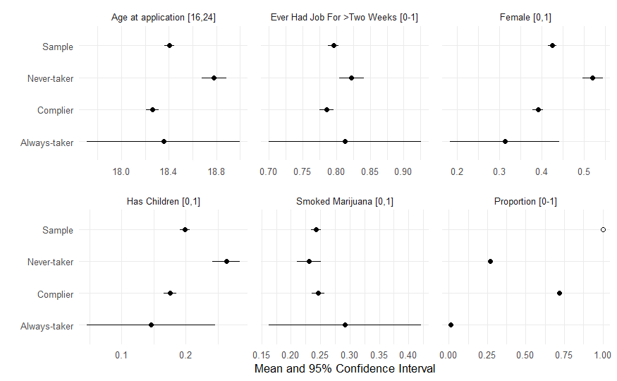